# Data Visualization Project

```r
library(tidyverse)
```

## Installing Package

```r
install.packages('AER')
```

## Packages

```r
library(AER)
```

```r
library(ggplot2)
```

```r
??AER
```

```
## starting httpd help server ... done
```

```r
data(package="AER")
```

```r
data("CreditCard")
```

## Take a Look at the Data

```r
glimpse(CreditCard)
```

```
## Rows: 1,319
## Columns: 12
## $ card        <fct> yes, yes, yes, yes, yes, yes, yes, yes, yes, yes, yes, no,~
## $ reports     <dbl> 0, 0, 0, 0, 0, 0, 0, 0, 0, 0, 0, 0, 0, 0, 0, 0, 0, 7, 0, 3~
## $ age         <dbl> 37.66667, 33.25000, 33.66667, 30.50000, 32.16667, 23.25000~
## $ income      <dbl> 4.5200, 2.4200, 4.5000, 2.5400, 9.7867, 2.5000, 3.9600, 2.~
## $ share       <dbl> 0.0332699100, 0.0052169420, 0.0041555560, 0.0652137800, 0.~
## $ expenditure <dbl> 124.983300, 9.854167, 15.000000, 137.869200, 546.503300, 9~
## $ owner       <fct> yes, no, yes, no, yes, no, no, yes, yes, no, yes, yes, yes~
## $ selfemp     <fct> no, no, no, no, no, no, no, no, no, no, no, no, no, no, no~
## $ dependents  <dbl> 3, 3, 4, 0, 2, 0, 2, 0, 0, 0, 1, 2, 1, 0, 2, 1, 2, 2, 0, 0~
## $ months      <dbl> 54, 34, 58, 25, 64, 54, 7, 77, 97, 65, 24, 36, 42, 26, 120~
## $ majorcards  <dbl> 1, 1, 1, 1, 1, 1, 1, 1, 1, 1, 1, 1, 0, 1, 0, 1, 1, 1, 1, 1~
## $ active      <dbl> 12, 13, 5, 7, 5, 1, 5, 3, 6, 18, 20, 0, 12, 3, 5, 22, 0, 8~
```

## Summary Of Data

```r
summary(CreditCard)
```

```
##   card         reports             age              income
##  no : 296   Min.   : 0.0000   Min.   : 0.1667   Min.   : 0.210
##  yes:1023   1st Qu.: 0.0000   1st Qu.:25.4167   1st Qu.: 2.244
##             Median : 0.0000   Median :31.2500   Median : 2.900
##             Mean   : 0.4564   Mean   :33.2131   Mean   : 3.365
##             3rd Qu.: 0.0000   3rd Qu.:39.4167   3rd Qu.: 4.000
##             Max.   :14.0000   Max.   :83.5000   Max.   :13.500
##      share            expenditure       owner     selfemp      dependents
##  Min.   :0.0001091   Min.   :   0.000   no :738   no :1228   Min.   :0.0000
##  1st Qu.:0.0023159   1st Qu.:   4.583   yes:581   yes:  91   1st Qu.:0.0000
##  Median :0.0388272   Median : 101.298                        Median :1.0000
##  Mean   :0.0687322   Mean   : 185.057                        Mean   :0.9939
##  3rd Qu.:0.0936168   3rd Qu.: 249.036                        3rd Qu.:2.0000
##  Max.   :0.9063205   Max.   :3099.505                        Max.   :6.0000
##      months         majorcards         active
##  Min.   :  0.00   Min.   :0.0000   Min.   : 0.000
##  1st Qu.: 12.00   1st Qu.:1.0000   1st Qu.: 2.000
##  Median : 30.00   Median :1.0000   Median : 6.000
##  Mean   : 55.27   Mean   :0.8173   Mean   : 6.997
##  3rd Qu.: 72.00   3rd Qu.:1.0000   3rd Qu.:11.000
##  Max.   :540.00   Max.   :1.0000   Max.   :46.000
```

## 1) Two plots displaying the distribution of a single continuous variable.

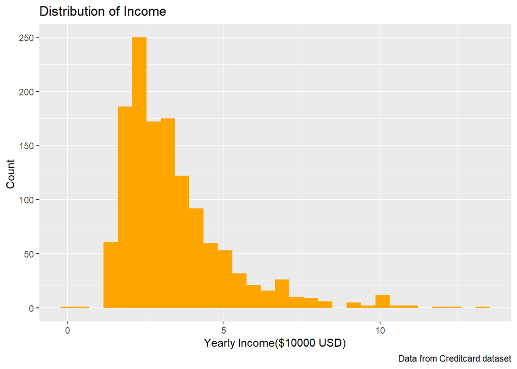

```r
ggplot(data=CreditCard)+
  geom_histogram(mapping=aes(x=income), fill="orange") +
  labs(x="Yearly Income($10000 USD)",y="Count ",title = "Distribution of Income",caption = "Data from Creditcard dataset")
```

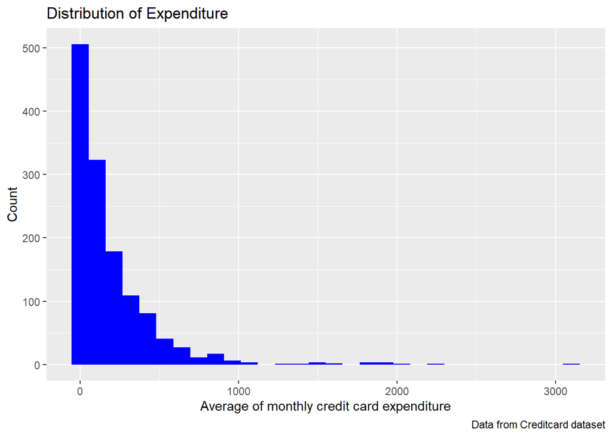

```r
ggplot(data=CreditCard)+
  geom_histogram(mapping=aes(x=expenditure), fill="blue") +
  labs(x="Average of monthly credit card expenditure",y="Count",title = "Distribution of Expenditure",caption = "Data from Creditcard dataset")
```

## 2) Two plots displaying information about a single categorical variable.

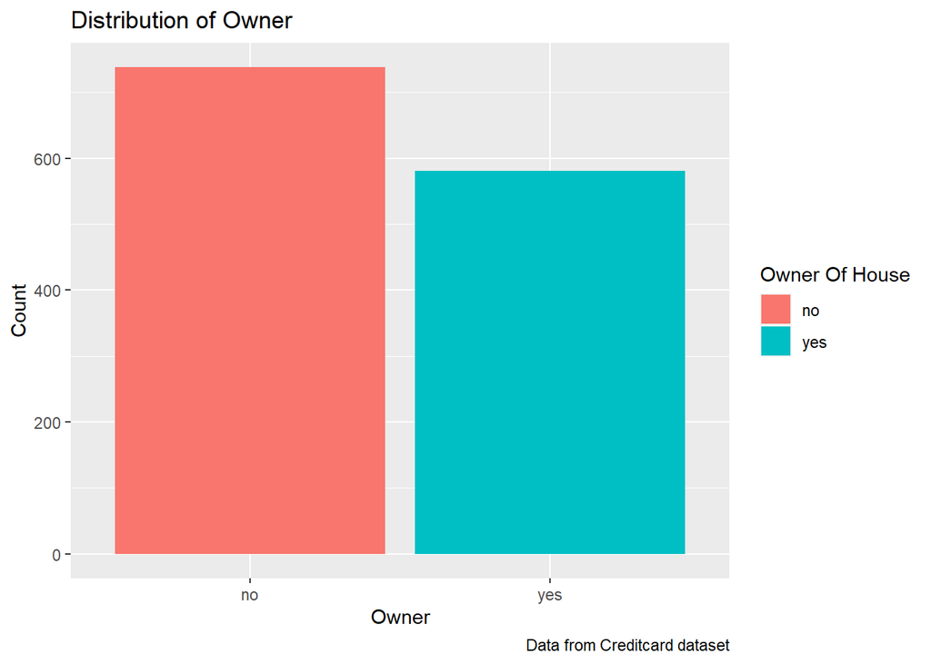

```r
ggplot(CreditCard) +
    geom_bar(mapping=aes(x=owner,fill=owner))+
    scale_fill_brewer(palette="Spectral")+
    scale_colour_brewer()+
    scale_fill_discrete(name="Owner Of House",
                        breaks=c("no", "yes"),
                        labels=c("no", "yes"))+
    labs(x="Owner",y="Count",title = "Distribution of Owner", caption = "Data from Creditcard dataset")
```

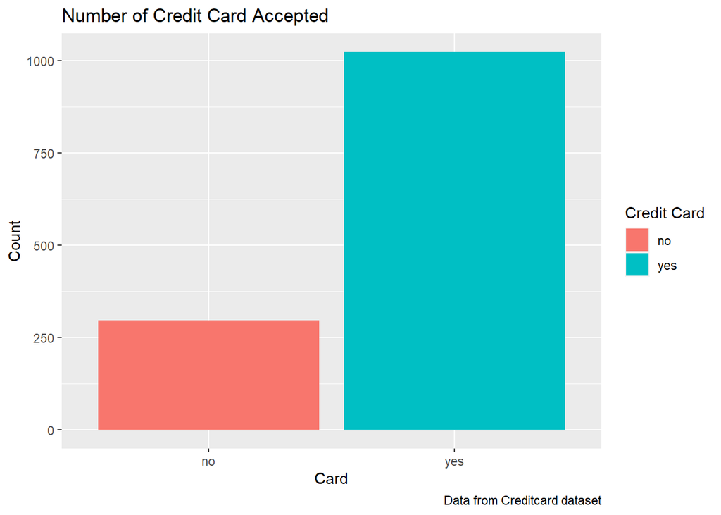

```r
ggplot(CreditCard) +
    geom_bar(mapping=aes(x=card,fill=card))+
    scale_fill_brewer(palette="Dark2")+scale_colour_brewer()+
    scale_fill_discrete(name="Credit Card",
                            breaks=c("no", "yes"),
                            labels=c("no", "yes"))+
    labs(x="Card",y="Count",title = "Number of Credit Card Accepted", caption = "Data from Creditcard dataset")+
    theme_grey()
```

## 3) One plot displaying information about both a continuous variable and a categorical variable.

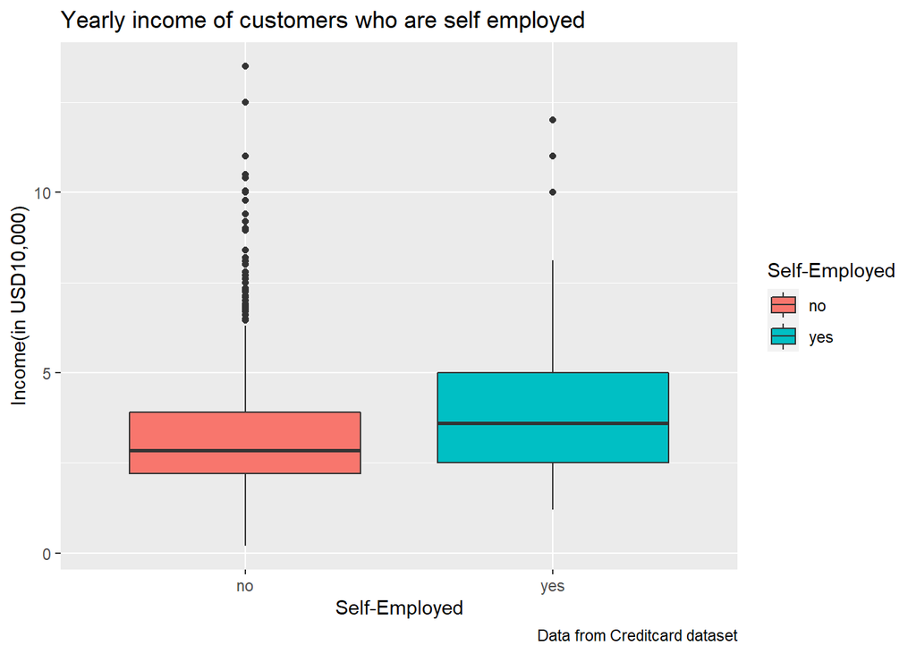

```r
ggplot(data=CreditCard, mapping = aes(x =selfemp , y =income,fill=selfemp)) +
      geom_boxplot() +
  theme_bw()+scale_fill_discrete(name="Self-Employed",
                         breaks=c("no", "yes"),
                         labels=c("no", "yes"))+
  labs(x="Self-Employed",y="Income(in USD10,000)",title = "Yearly income of customers who are self employed",caption = "Data from Creditcard dataset")+
  theme_grey()
```

## 4) Two plots should display information that shows a relationship between two variables

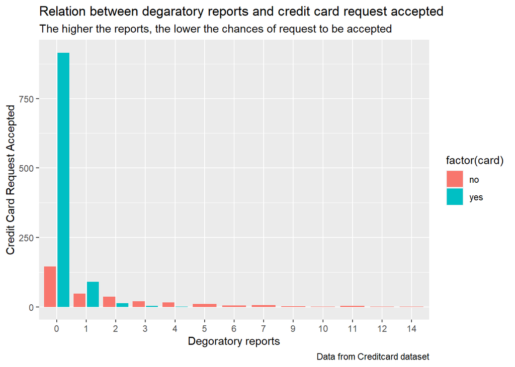

```r
ggplot(data = CreditCard, aes(factor(reports), fill = factor(card))) +
  geom_bar(position = "dodge2")+ labs(title = "Relation between degaratory reports and credit card request accepted", subtitle = "The higher the reports, the lower the chances of request to be accepted", caption = "Data from Creditcard dataset", x="Degoratory reports", y="Credit Card Request Accepted")
```

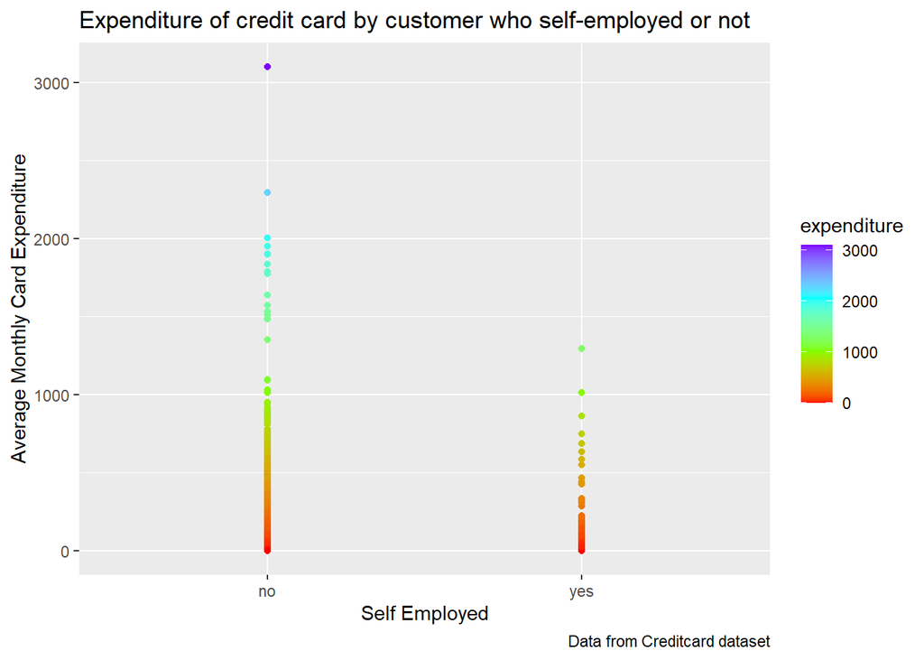

```r
ggplot(data=CreditCard, aes(x=selfemp, y=expenditure, colour=expenditure)) +
      geom_point() +
      scale_colour_gradientn(colours=rainbow(4))+
      labs(x="Self Employed",y="Average Monthly Card Expenditure",title = "Expenditure of credit card by customer who self-employed or not",caption = "Data from Creditcard dataset")
```

```r
  #guides(size= guide_legend(title = "Self Employed"))+
```

## 5) One plot should use faceting and display information about 4 variables

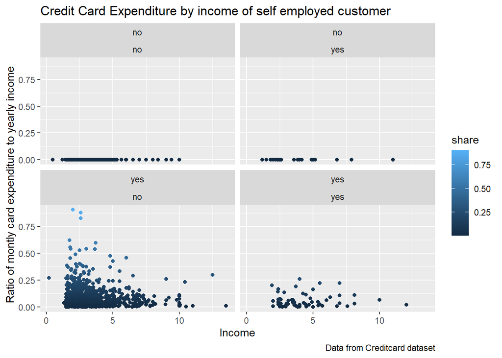

```r
ggplot(CreditCard)+
      geom_point(mapping = aes(x = income , y = share, colour=share))+
      facet_wrap(~card+selfemp)+
      labs(x="Income",y="Ratio of montly card expenditure to yearly income",title="Credit Card Expenditure by income of self employed customer",caption = "Data from Creditcard dataset")
```

## In what ways do you think data visualization is important to understanding a data set?

Data visualization is very vital and important tools for understanding the data effectively by presenting data inform easier to understand , highlighting the trends and by removing unwanted data from data set. So the data visualization is important to interpret more complicated data.

## In what ways do you think data visualization is important to communicating important aspects of a data set?

In a complex table data, it is hard for humans to look at uncountable data and make the meaning out of it. Data visualization makes it easier to look at such data by giving visual context or graphs. This makes it easier for human mind to comprehend data by elimination unnecessary data and makes it easier to identify trends and patterns.

## What role does your integrity as an analyst play when creating a data visualization for communicating results to others?

As an data analyst integrity is one of the most important quality of analyst because when dealing with sensitive information one must not manipulate data and should be presented in given form because if not done so we might have an inaccurate data visualization and might have impact on our decision.

## How many variables do you think you can successfully represent in a visualization? What happens when you exceed this number?

There will be two variables can easily and successfully represent data which conveys better meaning while when it exceeds the two variables it is difficult to analyze and visualize data.

## Team Contribution:

Stage 1: Firstly, we all search for datasets which we can use for the project 1.

Stage 2: Secondly, we discussed about every dataset which was selected by use and we choose the most appropriate dataset for the project1

Stage 3: Thirdly, after the discussion we all came to conclusion that each team member will plot every graph on the chosen dataset. In this way every team member has their version of project.

Stage 4: Finally, after the plotting was done, we discuss and finalize the best graphs for data visualization to solve questions.

## Name

1. Urali Virajsinh Rana(0789945)

## Contribution

1. Two plots displaying the distribution of a single continuous variable (2 graphs plotted).
2. One plot should use faceting and display information about 4 variables(1 graph plotted)

## Name

2. Devkumar Navnitkumar Patel(0787429)

## Contribution

1. Two plots displaying information about a single categorical variable.
2. One plot displaying information about both a continuous variable and a categorical variable.

## Name

3. Rajan Atulkumar Patel(0789953)

## Contribution

1. Two plots should display information that shows a relationship between two variables
2. Answered to the 4 theory question

## References

1. Dataset link: https://vincentarelbundock.github.io/Rdatasets/doc/AER/CreditCard.html
2. ggplot for color : http://www.cookbook-r.com/Graphs/